# twitter

## Gather Tweets

```r
library(lubridate)
cat(paste('Gathered on ',month(ymd(Sys.Date()),label = T), ' ',
          day(ymd(Sys.Date())),',',year(ymd(Sys.Date())),sep = ''))
```

```
## Gathered on Feb 12,2022
```

```r
library(rtweet)
tweets = search_tweets(q = 'JoeBiden',n = 1000, include_rts = F)
```

To export and save data use the following code after setting your working directory. To set your working directory, modify the following to set the file path for the folder where the data file resides. `setwd('c:/thatawesomeclass/)`

```r
save_as_csv(tweets,'tweets.csv', prepend_ids =TRUE, na ="")
```

Review a few tweets

```r
head(tweets)
```

| user_id | status_id | created_at | screen_name | text | source | display_text_width | reply_to_status_id | reply_to_user_id | reply_to_screen_name | is_quote | is_retweet | favorite_count | retweet_count | quote_count | reply_count | hashtags | symbols | urls_url | urls_t.co | urls_expanded_url | media_url | media_t.co | media_expanded_url | media_type | ext_media_url | ext_media_t.co | ext_media_expanded_url | ext_media_type | mentions_user_id | … |
| --- | --- | --- | --- | --- | --- | --- | --- | --- | --- | --- | --- | --- | --- | --- | --- | --- | --- | --- | --- | --- | --- | --- | --- | --- | --- | --- | --- | --- | --- | --- |
| 2240074220 | 1492402797429493762 | 2022-02-12 07:38:49 | acquitted24 | @hatejacktoo @LawyerOnSkis @JoeBiden When did they let you out of the psychiatric Institute. You should probably take your meds. Probably double up. | Twitter for Android | 111 | 1492392687345057794 | 1453155411620765696 | hatejacktoo | FALSE | FALSE | 0 | 0 | NA | NA |  |  |  |  |  |  |  |  |  |  |  |  | NA |  | … |
| 23336276 | 1492402778580430852 | 2022-02-12 07:38:44 | EdgarCorley | @Heavens_shoppe @JoeBiden That doesn’t make sense considering there still cars continue education specialization in electrical vehicles it’s not like the billions of gas cars are gonna disappear overn… | Twitter for iPhone | 244 | 1492300735215804416 | 2381226350 | Heavens_shoppe | FALSE | FALSE | 0 | 0 | NA | NA |  |  |  |  |  |  |  |  |  |  |  |  | NA |  | … |
| 36409600 | 1492402769587838978 | 2022-02-12 07:38:42 | birdmanbob4 | @Asensii20 @JoeBiden I'll just fucking make him King then | Twitter for Android | 36 | 1492241104145723392 | 770001997550551041 | Asensii20 | FALSE | FALSE | 0 | 0 | NA | NA |  |  |  |  |  |  |  |  |  |  |  |  | NA |  | … |
| 36409600 | 1492401872354914305 | 2022-02-12 07:35:08 | birdmanbob4 | @Heavens_shoppe @JoeBiden Those must be the old throw away people that they wanted to kill off during the pandemic | Twitter for Android | 88 | 1492300735215804416 | 2381226350 | Heavens_shoppe | FALSE | FALSE | 0 | 0 | NA | NA |  |  |  |  |  |  |  |  |  |  |  |  | NA |  | … |
| 36409600 | 1492401499435114500 | 2022-02-12 07:33:39 | birdmanbob4 | @AlisonBoxxer @JoeBiden full of shit like Joe let's go Brandon | Twitter for Android | 38 | 1492241385491243009 | 1333774146807980033 | AlisonBoxxer | FALSE | FALSE | 0 | 0 | NA | NA |  |  |  |  |  |  |  |  |  |  |  |  | NA |  | … |
| 1478805790446080000 | 1492402750369710080 | 2022-02-12 07:38:37 | kimthanhsang | @BTNFINANCE good project @jack @JoeBiden @TheCryptoLark | Twitter for Android | 43 | 1491001022579310595 | 1399881128799096841 | BTNFINANCE | FALSE | FALSE | 0 | 0 | NA | NA |  |  |  |  |  |  |  |  |  |  |  |  | NA |  | … |

```r
tweets[1:10,c('screen_name','text')]
```

| screen_name | text |
| --- | --- |
| acquitted24 | @hatejacktoo @LawyerOnSkis @JoeBiden When did they let you out of the psychiatric Institute. You should probably take your meds. Probably double up. |
| EdgarCorley | @Heavens_shoppe @JoeBiden That doesn’t make sense considering there still cars continue education specialization in electrical vehicles it’s not like the billions of gas cars are gonna disappear overn… |
| birdmanbob4 | @Asensii20 @JoeBiden I'll just fucking make him King then |
| birdmanbob4 | @Heavens_shoppe @JoeBiden Those must be the old throw away people that they wanted to kill off during the pandemic |
| birdmanbob4 | @AlisonBoxxer @JoeBiden full of shit like Joe let's go Brandon |
| kimthanhsang | @BTNFINANCE good project @jack @JoeBiden @TheCryptoLark |
| Stizmaster | @debbieditybaby @joeecollins3 @JoeBiden @RepMaxineWaters Remember better… because you’re lying |
| ba110ba | @JoeBiden @ABlinken @thejointstaff @SenSchumer @SpeakerPelosi (1 of 2) it's important to work with President Zelensky in Kiev to move him ; other top brass to another safe location so when attacked by… |
| ba110ba | @JoeBiden @ABlinken @thejointstaff @SenSchumer @SpeakerPelosi (1 of 2) The US, as an ally at least, needs to show that we're not fools with Russia's potential invasion. We need to show Russia we will … |
| ba110ba | @JoeBiden @ABlinken @thejointstaff @SenSchumer @SpeakerPelosi (2 of 2) As an ally to Ukraine, we need to a) bring in the latest Patriot missile systems with our own crew to run them b) have F16s (w/ a… |

Extract words from all tweets. Examine first fifty rows of data. Note the change in the data from wide format to a long/tall format.

```r
library(tidytext); library(dplyr)

tweets_words = tweets%>%
  group_by(screen_name)%>%
  unnest_tokens(output = word,input = text)%>%
  ungroup()%>%
  mutate(row=1:n())
as.data.frame(tweets_words)[1:50,c('screen_name','word')]
```

|  | screen_name | word |
| --- | --- | --- |
| 1 | acquitted24 | hatejacktoo |
| 2 | acquitted24 | lawyeronskis |
| 3 | acquitted24 | joebiden |
| 4 | acquitted24 | when |
| 5 | acquitted24 | did |
| 6 | acquitted24 | they |
| 7 | acquitted24 | let |
| 8 | acquitted24 | you |
| 9 | acquitted24 | out |
| 10 | acquitted24 | of |

[output cut: 40 more lines]

## Binary Sentiment

There are a number of word lexicons that can be used to classify words as being positive or negative. The [Bing lexicon](https://www.cs.uic.edu/~liub/FBS/sentiment-analysis.html) categorizes words as being positive and negative.

```r
as.data.frame(get_sentiments('bing'))[1:50,]
```

|  | word | sentiment |
| --- | --- | --- |
| 1 | 2-faces | negative |
| 2 | abnormal | negative |
| 3 | abolish | negative |
| 4 | abominable | negative |
| 5 | abominably | negative |
| 6 | abominate | negative |
| 7 | abomination | negative |
| 8 | abort | negative |
| 9 | aborted | negative |
| 10 | aborts | negative |

[output cut: 40 more lines]

```r
get_sentiments('bing')%>%
  group_by(sentiment)%>%
  count()%>%
  ungroup()
```

| sentiment | n |
| --- | --- |
| negative | 4781 |
| positive | 2005 |

### Bing

Using the Bing Lexicon we can categorize all words in the tweets by valence. Here is a summary chart of positive and negative words

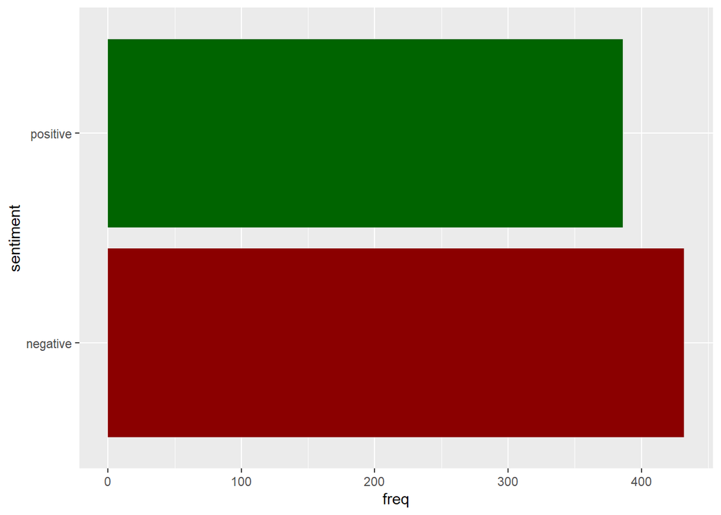

```r
library(ggplot2)
tweets_words %>%
  inner_join(get_sentiments('bing'),by = 'word')%>%
  select('sentiment')%>%
  group_by(sentiment)%>%
  summarize(freq=n())%>%
  ungroup()%>%
  ggplot(aes(x=sentiment,y=freq))+geom_bar(position='dodge',
                                           stat='identity',fill=c('darkred','darkgreen'))+
  coord_flip()
```

## Sentiment Score

Another popular Lexicon is AFINN. This lexicon (available [here](http://www2.imm.dtu.dk/pubdb/views/publication_details.php?id=6010)) of words assigns scores words on the extent to which they are positive or negative. To make this code portable and seamless, the afinn lexicon has been placed on github from where it is being read in. Another alternative is to use get_sentiments(‘afinn’) from library(tidytext) but it does not work in non-interactive mode

```r
afinn = read.table('https://raw.githubusercontent.com/pseudorational/data/master/AFINN-111.txt',
                   header=F, sep='\t', col.names=c('word','value'))
afinn[1:50,]
```

|  | word | value |
| --- | --- | --- |
| 1 | abandon | -2 |
| 2 | abandoned | -2 |
| 3 | abandons | -2 |
| 4 | abducted | -2 |
| 5 | abduction | -2 |
| 6 | abductions | -2 |
| 7 | abhor | -3 |
| 8 | abhorred | -3 |
| 9 | abhorrent | -3 |
| 10 | abhors | -3 |

[output cut: 40 more lines]

```r
afinn %>%
  group_by(value)%>%
  count()
```

| value | n |
| --- | --- |
| -5 | 4 |
| -4 | 4 |
| -3 | 43 |
| -2 | 99 |
| -1 | 49 |
| 1 | 33 |
| 2 | 68 |
| 3 | 35 |
| 4 | 3 |
| 5 | 1 |

[output cut: 1 more lines]

### Scores all words

By applying the afinn lexicon to the words in the tweets, we can compute a score for each tweet. By averaging the scores of all tweets, one can obtain an overall sentiment score.

Here is a histogram of the scores of all words in the tweets.

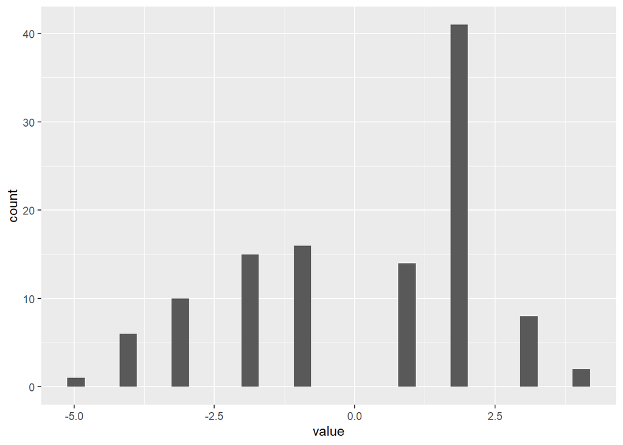

```r
tweets_words %>%
  inner_join(afinn,by = 'word')%>%
  select('value')%>%
  ggplot(aes(x=value))+geom_histogram()
```

### Score each tweet

Here is a histogram of the scores of each tweet

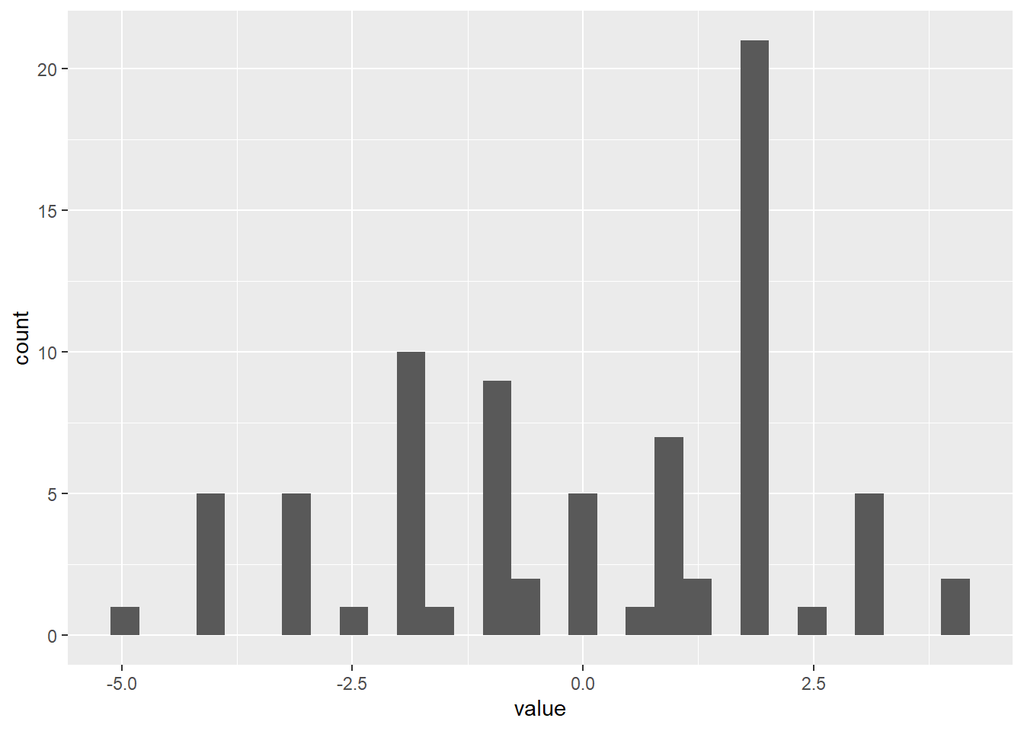

```r
tweets_words %>%
  left_join(afinn,by = 'word')%>%
  group_by(screen_name)%>%
  summarize(value = mean(value,na.rm=T))%>%
  ungroup()%>%
  select('screen_name','value')%>%
  ggplot(aes(x=value))+geom_histogram()
```

### Sentiment Score

Sentiment score is the average of the sentiment of all tweets. First, we get the sentiment for each tweet

```r
tweets_words %>%
  inner_join(afinn,by = 'word')%>%
  group_by(screen_name)%>%
  summarize(tweet_sentiment = mean(value,na.rm=T))%>%
  ungroup()
```

| screen_name | tweet_sentiment |
| --- | --- |
| AbdulGhafoor_Ar | -1.00 |
| AlexWitzleben | 0.50 |
| aprilmorton73 | -4.00 |
| AZ_IBM_7090 | 1.00 |
| ba110ba | 0.00 |
| BaaghiTV | 2.00 |
| balalogy | 0.00 |
| BBJAKK1 | -2.00 |
| BlingWendy | -3.00 |
| chadsecor | 2.00 |

[output cut: 68 more lines]

```r
tweets_words %>%
  inner_join(afinn,by = 'word')%>%
  group_by(screen_name)%>%
  summarize(tweet_sentiment = mean(value,na.rm=T))%>%
  ungroup()%>%
  summarize(Overall_Sentiment=mean(tweet_sentiment,na.rm=T))
```

| Overall_Sentiment |
| --- |
| 0.04038462 |

## Emotions

A word may reflect more than just valence. The ‘nrc’ lexicon categorizes words by emotion. This lexicon which was previously a part of library(tidytext) was dropped from the package as of June 14, 2019. The lexicon was copied from its non-commercial use link and posted to github. This lexicon and a number of others can be found [here](http://sentiment.nrc.ca/lexicons-for-research/) but its free use is limited to non-commercial purposes. The following code will place the lexicon in a dataframe called nrc.

```r
nrc = read.table(file = 'https://raw.githubusercontent.com/pseudorational/data/master/nrc_lexicon.txt',
                 header = F,col.names = c('word','sentiment','num'),sep = '\t');
                            nrc = nrc[nrc$num!=0,]; nrc$num = NULL
```

Summary of the number of words in the lexicon reflecting each emotion

```r
nrc%>%
  group_by(sentiment)%>%
  count()
```

| sentiment | n |
| --- | --- |
| anger | 1247 |
| anticipation | 839 |
| disgust | 1058 |
| fear | 1476 |
| joy | 689 |
| negative | 3324 |
| positive | 2312 |
| sadness | 1191 |
| surprise | 534 |
| trust | 1231 |

### Chart

Chart of Words reflecting Emotion

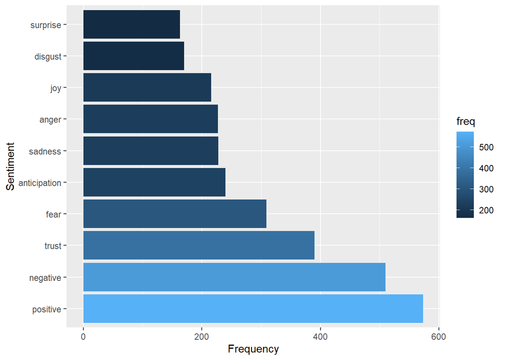

```r
library(RColorBrewer)
tweets_words %>%
  inner_join(get_sentiments('nrc'),by = 'word')%>%
  select('sentiment')%>%
  group_by(sentiment)%>%
  summarize(freq=n())%>%
  ungroup() %>%
  ggplot(aes(x=reorder(sentiment,desc(freq)),y=freq,fill=freq))+
      geom_bar(position='dodge',stat='identity')+
      xlab('Sentiment')+ylab('Frequency')+coord_flip()
```

## Visualizing Text

### Word Cloud

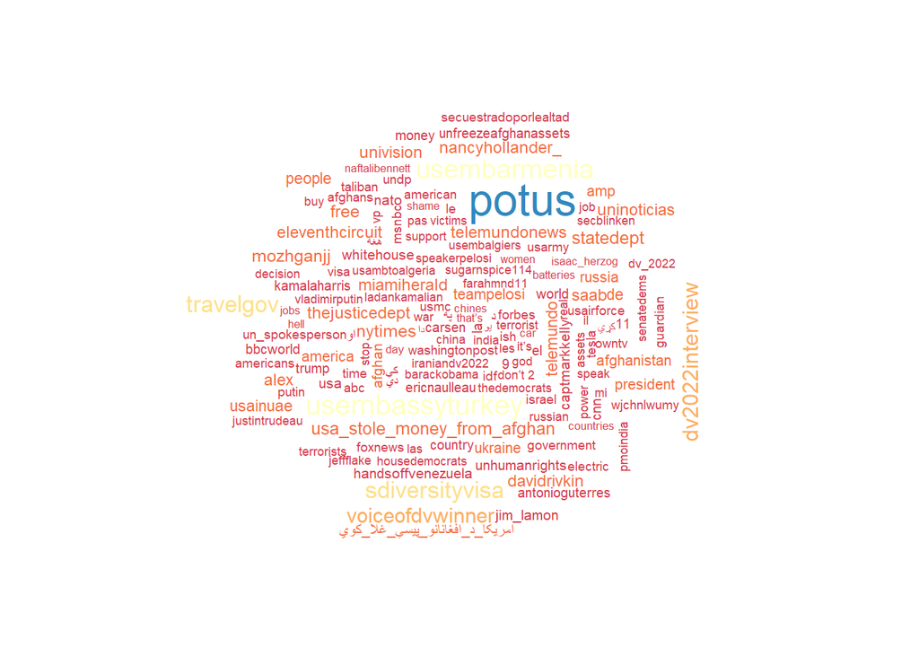

```r
library(tidyr); library(wordcloud)
wordcloud_data=
  tweets_words %>%
  anti_join(rbind(stop_words,c('joe','SMART'),c('biden','SMART'),c('joebiden','SMART'),
                  c('https','SMART'),c('t.co','SMART')),by='word')%>%
  count(word,sort=T)%>%
  ungroup()
wordcloud_data= as.data.frame(wordcloud_data)

wordcloud(words = wordcloud_data$word,wordcloud_data$n,scale=c(2,0.5),
          max.words = 150,colors=brewer.pal(9,"Spectral"))
```

### Comparison Cloud

A comparison cloud comparing Positive words to Negative Words

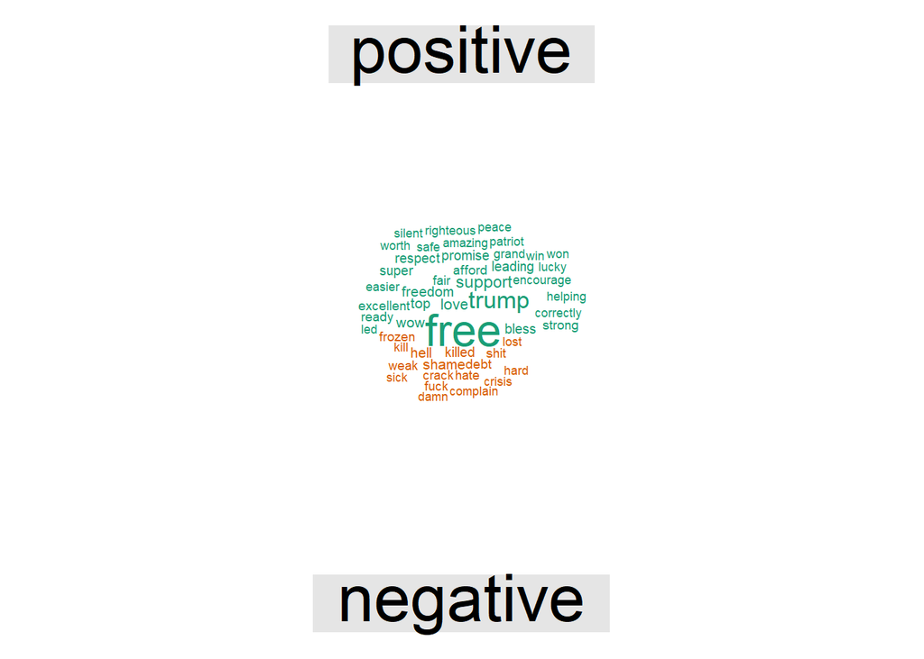

```r
library(tidyr); library(wordcloud)
wordcloud_data=
  tweets_words %>%
  anti_join(stop_words,by='word')%>%
  inner_join(get_sentiments('bing'), by='word')%>%
  count(sentiment,word, sort=T)%>%
  ungroup()%>%
  spread(key=sentiment ,value='n', fill=0)
wordcloud_data= as.data.frame(wordcloud_data)
rownames(wordcloud_data) = wordcloud_data[,'word']
wordcloud_data = wordcloud_data[,c('positive','negative')]
comparison.cloud(wordcloud_data,scale=c(2,0.5), max.words= 50, rot.per=0)
```

This file was generated using R Version 4.1.2